# Data Handling: Import, Cleaning and Visualisation

Exercise/Workshop 1: Tools, Working with Text Files

Dr. Aurélien Sallin

01/10/2023

# Prerequisites

- Sign in to Nuvolos here: https://az.nuvolos.cloud/login using your Unisg E-Mail address.
- Nuvolos is a cloud-based service that allows you to use R and the IDE RStudio through your browser. In the scope of this course, there is no need to install R locally on your machine.
- If you do not have a GitHub account, you can create one here (not required for exam): https://github.com/join. Accounts are free. No need to use your Unisg E-Mail address.

# Part I: Introduction

# Why R?[^1]

## The ‘data language’

The programming language and open-source statistical computing environment R has over the last decade become a core tool for data science in industry and academia. It was originally designed as a tool for statistical analysis. Many characteristics of the language make R particularly useful to work with data. With the rise of the ‘data economy’ and ‘data science’, R is increasingly used in various domains, going well beyond the traditional applications of academic research.

## High-level language, relatively easy to learn

R is a relatively easy computer language to learn for people with no previous programming experience. The syntax is rather intuitive and error messages not too cryptic to understand (facilitates learning by doing). Moreover, with R’s recent stark rise in popularity, there are plenty of freely accessible resources online that help beginners to learn the language.

## Free, open-source, large community

Due to its vast base of contributors, R serves as a valuable tool for users in various fields related to data analysis and computation (economics/econometrics, biomedicine, business analytics, etc.). R users have direct access to thousands of freely available ‘R-packages’ (small software libraries written in R), covering diverse aspects of data analysis, statistics, data preparation, and data import.

Hence, a lot of people using R as a tool in their daily work do not actually ‘write programs’ (in the traditional sense of the word) but apply those packages. Applied econometrics with R is a good example of this. Almost any function a modern commercial computing environment with a focus on statistics and econometrics (such as [STATA](http://www.stata.com/)) is offering can also be found within the R environment. Furthermore, there are R packages covering all the areas of modern data analytics, including natural language processing, machine learning, big data analytics, etc. (see the [CRAN Task Views](https://cran.r-project.org/web/views/) for an overview). We thus do not actually have to write a program for many tasks we perform with R. Instead, we can build on already existing and reliable packages.

# The tools: R/RStudio

R is the high-level (meaning ‘more user friendly’) programming language for statistical computing. Once we have installed R on our computer, we can run it…

1. …locally:
- Install the latest R version. R is open-source and freely available from here: https://stat.ethz.ch/CRAN/. Click on the respective link for your operating system (Windows, Mac, Linux), and follow the instructions.
- Once R is installed, install RStudio from here: https://www.rstudio.com/products/rstudio/download/#download. Under “Installers for Supported Platforms”, click on the respective installer for your operating system (Windows, Mac, etc.) and follow the instructions.
3. …using Nuvolos:

[figure not shown]

Running R in RStudio (IDE).

The latter is what we will do throughout this course.

In the following, we have a look at each of the main panels we will use in this course.

## The R-Console

When working in an interactive session, we simply type R commands directly into the R console. Typically, the output R returns, when we give it a command this way, is printed in the console as well.

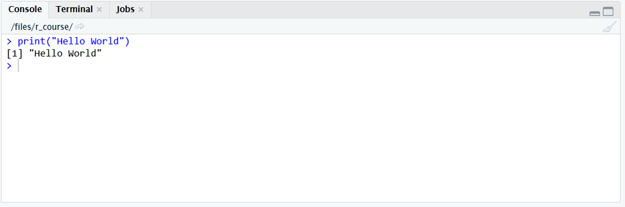

For example, we can tell R to print the phrase `Hello world` to the console by typing to following command in the console and hitting enter:

```r
print("Hello world")
```

```
## [1] "Hello world"
```

## R-Scripts

Apart from very short interactive sessions, it usually makes sense to write R code not directly in the command line but to a R-script in the script panel. This way, execute several lines at once, comment the code (to explain what it does), save it on our hard disk, and further develop the code later on.

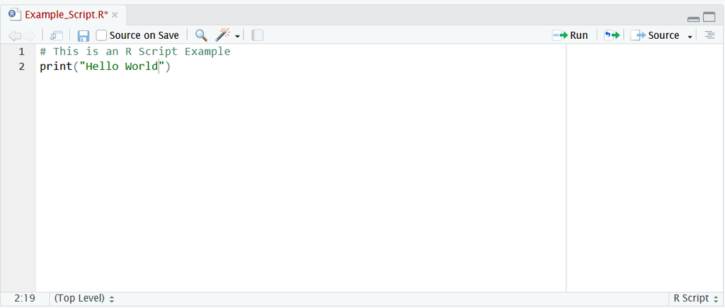

The R Script window in RStudio.

## R Environment

The environment pane shows what variables, objects, and data are loaded in our current R session. Moreover, it offers functions to open documents and import data.

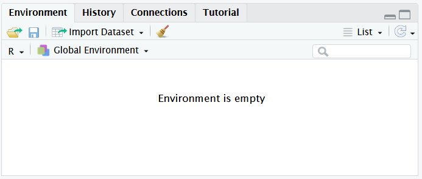

The environment window in RStudio.

## File Browser

With the File browser window, we can navigate through the folder structure and files on our computer’s hard disk, modify files, and set the working directory of our current R session. Moreover, it has a pane to show plots generated in R and a pane with help pages and R documentation.

[figure not shown]

The file browser window in RStudio.